# Lebesgue integral

### **NOTES ON STATISTICS, PROBABILITY and MATHEMATICS**

### Abstract Integration:

Abstract integration relies on a measurable space, $(\Omega,\mathcal F, \mu)$ and an $\mathcal F$-measurable function, $f: \Omega \to \mathbb R,$ which in probability theory is a random variable.

The integral

$$\int_A f \;\mathrm d\mu$$

is the integral over a measurable set $A$ of an $\mathcal F$-measurable function, $f$ with respect to a measure $\mu.$

In the specific case when $(\Omega,\mathcal F, \mu)= (\mathbb R,\mathcal B(\mathbb R), \lambda),$ i.e. $f: \mathbb R \to \mathbb R$ is a Borel-measurable function with the Lebesgue measure $\lambda,$ then $\int f\;\mathrm d \lambda$ is called the Lebesgue integral. Another specific case is the expectation of a random variable $X:\Omega \to \mathbb R$ on a probability space is defined as $\int X \; \mathrm d\mathbb P.$

If the integral occurs over the entire sample space it will be implicit in the notation:

$$\int_\Omega f \;\mathrm d\mu= \int f
\;\mathrm d\mu$$

Simple functions assume finitely many values in their image, and can be written as

$$f(\omega)= \sum_{i=1}^n a_i \mathbb
I_{A_i}(\omega), \quad \forall \omega \in \Omega$$

where $a_i \geq 0, \forall i \in \{1,2,3, \dots, n\},$ and $A_i \in \mathcal F, \forall i.$

Given the finite values in the image of the simple function $f,$ corresponding to each of $n$ disjoint subsets of $\Omega,$ such that $\bigcup_{i}A_i=\Omega,$ a simple function can indeed be written as:

$$f(\omega)=a_1 \mathbb I_{A_i}(\omega) +
a_2 \mathbb I_{A_2}(\omega)+\cdots +a_n\mathbb I_{A_n}(\omega)
=\sum_{i=1}^n a_i \mathbb I_{A_i}(\omega).$$

indicating that $a_i$ will the only value in the sum if it matches the subset $A_i$ according to the $i$ indexation, akin to a for-loop call in programming: only the $a_i$ corresponding to $\mathbb I_{A_i} (\omega)=1,$ i.e. when the outcome is in the measurable set $A_i,$ is ultimately represented.

The definition of the abstract integral of non-negative functions $f: \Omega \to \mathbb R_+$ is defined as the supremum of collection of simple functions that approximate $f$ from below:

Given a collection of simple functions $q: \Omega \to \mathbb R_+$ denoted $S(f)=\{s_1, s_2, \dots, s_N\},$ for some $N \in \mathbb N,$ such that for all $\omega \in \Omega$ it fulfills $q(\omega)\leq f(\omega),$ the abstract integral is defined as

$$\int_\Omega f \;\mathrm d\mu=\sup_{q \in
S(f)} \int q \;\mathrm d\mu=\sup\left(\sum_{q\in S(f)} q \; \mu
(\text{preim}\left(\{q\})\right) \right)$$

There is still need to a practical method to approximating or computing this integral. The following is such a method:

$$\int_\Omega f \;\mathrm d\mu = \lim_{n
\to \infty} \int f_n \mathrm d\mu$$
where

$$f_n(x) =
\sum_{k=0}^{n2^n-1}\frac{k}{2^n}\; \chi_{\frac{k}{2^n}\leq
f(x)<\frac{k+1}{2^n}}\; +\; n\,\chi_{f(x) \geq n}$$

and letting $n \to \infty.$

The range or codomain of the function $f$ is partitioned fixing a maximum value $n$ from $k=0$ to $k = n$ at intervals $\frac{k}{2^n}$ in order to define a sequence of simple functions $f_n$ with value $n$ if $f(\omega)$ is equal or greater than $n,$ and otherwise with the lowest value for that interval, $n-\frac{1}{2^n}.$

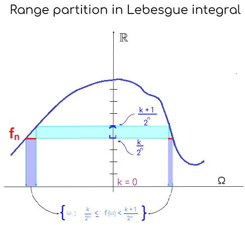

Coding a concept helps, so I tried doing so for [this post](https://math.stackexchange.com/a/7444/152225), illustrating the Lebesgue integral of $y = x^2$ between $[0,1]$. The code is [here](https://github.com/RInterested/SIMULATIONS_and_PROOFS/blob/master/Lebesgue%20plot), and the output looks like this:

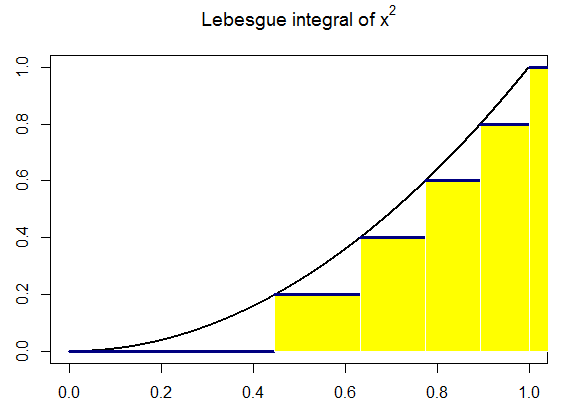

Finally, here is a systematic “construction” of the Lebesgue integral for an inverted parabola, really showing how the critical step is to partition the range (y axis) in $N$ equally spaced divisions between the $y$ limits of integration, defining $[y_i,y_{i+1}]$ intervals, and look for the measure of the pre-image in the $x$ axis: the difference between the inverse function at a given chosen point, $y^*$ (not a slab) for any given $[y_i, y_{i+1}]$ interval, $f^{-1}(y^*_i)$, and the inverse of the next point in the y axis, $y^*_{i+1}$. Analytically, this “strategy” relies ultimately in letting $N\rightarrow\infty$, which explains the “pyramid” iconography so often found online, which is intuitive, but has the potential to suggest the integral as a pile of horizontal slabs. This was a big hurdle understanding the difference between the Lebesgue and the Darboux integrals. Here is an attempt at a more faithful dynamic representation (again the [code](https://github.com/RInterested/SIMULATIONS_and_PROOFS/blob/master/Lebesgue%20plot) is here waiting for improvements):

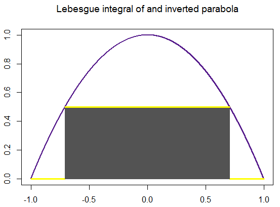

[Home Page](http://rinterested.github.io/statistics/index.html)

**NOTE: These are tentative notes on different topics for personal use - expect mistakes and misunderstandings.**